# ENVS 193DS Homework 3

Published

May 27, 2025

**Name:** Fiona Jeweler  
**Date:** May 27, 2025

## Part 1: Set Up Tasks

[Link to GitHub Repository](https://github.com/fionajeweler1/ENVS-193DS_homework-03)

## Part 2: Problems

### a.

To compare how quickly I fall asleep on days when I meet my recommended activity goal versus when I do not, I will calculate the mean time to fall asleep for each group (“Yes” vs. “No” under “Meet daily recommended activity goal”). This allows me to compare average sleep onset times between more and less active days. Comparing means is informative because if there is a noticeable difference, it could suggest a relationship between physical activity levels and how quickly I fall asleep.

### b.

```r
colnames(data)
```

```
[1] "Date"
[2] "Time to fall asleep (minutes)"
[3] "Total calories burned"
[4] "Caffeine Intake (ml)"
[5] "Steps"
[6] "Time inactive"
[7] "Meet daily recommended activity goal"
```

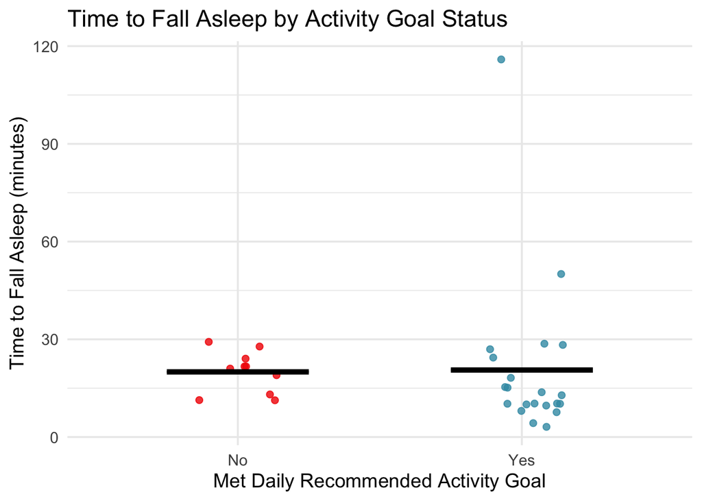

```r
#Clean column names
data <- janitor::clean_names(data)

#Renaming column names
data <- data %>%
  rename(
    time_to_sleep = time_to_fall_asleep_minutes,
    met_goal = meet_daily_recommended_activity_goal
  )

# Creating plot
ggplot(data, aes(x = met_goal, y = time_to_sleep, color = met_goal)) +
  geom_jitter(width = 0.15, size = 2, alpha = 0.8) +
  stat_summary(fun = mean, geom = "crossbar", width = 0.5,
               color = "black", fatten = 3, size = 0.6,
               aes(ymin = after_stat(y), ymax = after_stat(y))) +  # updated for deprecation
  scale_color_manual(values = c("Yes" = "#3B9AB2", "No" = "#F21A00")) +
  labs(
    x = "Met Daily Recommended Activity Goal",
    y = "Time to Fall Asleep (minutes)",
    title = "Time to Fall Asleep by Activity Goal Status"
  ) +
  theme_minimal(base_size = 14) +
  theme(legend.position = "none")
```

### d.

```r
# Creating summary table
summary_table <- data %>%
  group_by(met_goal) %>%
  summarise(
    mean_time_to_sleep = round(mean(time_to_sleep, na.rm = TRUE), 1),
    n = n()
  ) %>%
  rename(
    `Met Activity Goal` = met_goal,
    `Mean Time to Fall Asleep (minutes)` = mean_time_to_sleep,
    `Sample Size` = n
  )

# Generating GT table
summary_table %>%
  gt() %>%
  tab_header(
    title = "Average Time to Fall Asleep by Activity Goal Status"
  )
```

Average Time to Fall Asleep by Activity Goal Status

| Met Activity Goal | Mean Time to Fall Asleep (minutes) | Sample Size |
| --- | --- | --- |
| No | 20.0 | 10 |
| Yes | 20.6 | 21 |

## Part 3: Affective visualization

### b.

Here is a sketch representing the visual idea I described above.

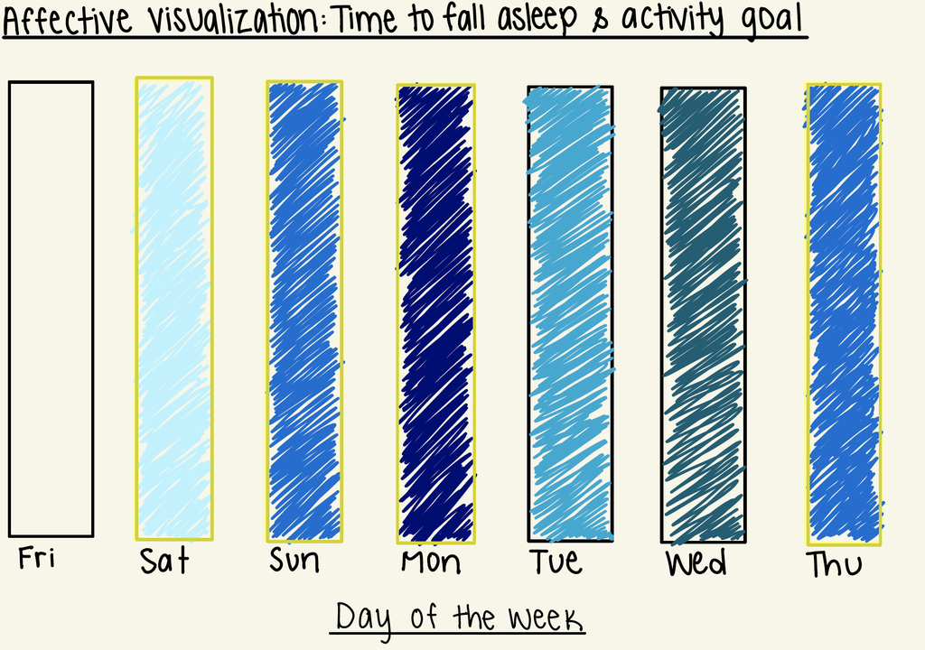

### c.

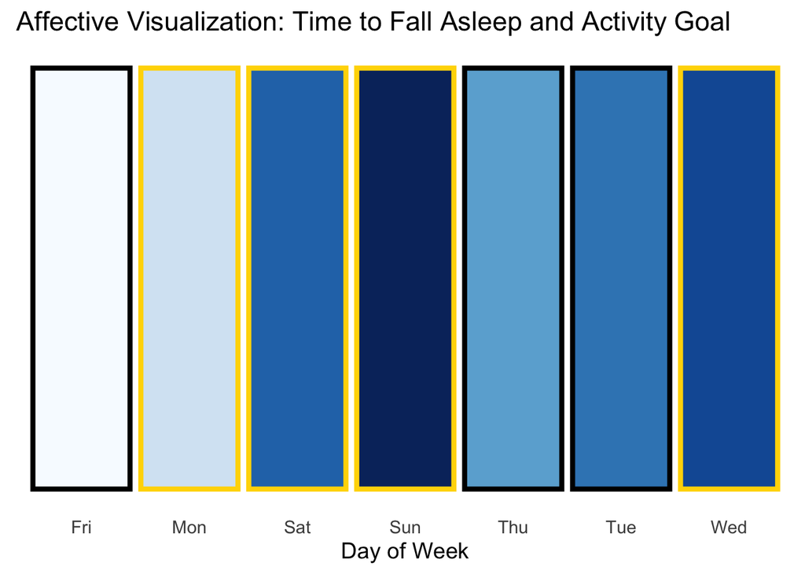

```r
# Sample data
data <- data.frame(
  Day = c("Mon", "Tue", "Wed", "Thu", "Fri", "Sat", "Sun"),
  Time_to_sleep = c(35, 20, 15, 25, 40, 18, 10),
  Met_goal = c(TRUE, FALSE, TRUE, FALSE, FALSE, TRUE, TRUE)
)

# Normalize sleep time to control color lightness
data <- data %>%
  mutate(
    norm_sleep = (Time_to_sleep - min(Time_to_sleep)) / (max(Time_to_sleep) - min(Time_to_sleep)),
    fill_color = scales::col_numeric("Blues", domain = NULL)(1 - norm_sleep),
    border_color = ifelse(Met_goal, "gold", "black")
  )

# Plot
ggplot(data, aes(x = Day, y = 1, fill = fill_color)) +
  geom_col(color = data$border_color, size = 1.5, show.legend = FALSE) +
  scale_fill_identity() +
  labs(
    title = "Affective Visualization: Time to Fall Asleep and Activity Goal",
    x = "Day of Week", y = NULL
  ) +
  theme_minimal(base_size = 14) +
  theme(
    axis.text.y = element_blank(),
    axis.ticks.y = element_blank(),
    panel.grid = element_blank()
  )
```

### d.

This piece is influenced by affective visual artists like Jill Pelto, whose work transforms environmental data into emotionally resonant imagery. I was also inspired by the aesthetic simplicity of the “Dear Data” project by Posavec and Lupi, which communicates intimate, personal metrics through minimal visuals.

The form of my work is a digital bar visualization created using R and the ggplot2 package. I chose this form to maintain both structure and emotion, using code to generate a color-based interpretation of how my body transitions into rest.

## Part 4: Statistical critique

### a.

The authors use multiple statistical tests, including Welch’s two-sample t-tests and General Linear Models (GLMs). Welch’s t-tests are used to compare mean parasite burdens (e.g., egg or oocyst counts) between groups such as juveniles vs. adults or July vs. October. GLMs are used to examine how parasite prevalence and intensity are influenced by multiple predictor variables including age class, sex, month of sampling, year, and land cover type. These tests help assess whether the observed differences in parasite burden are statistically significant and related to the authors’ key demographic and environmental factors.

Figure 2 from Wait et al. (2023). Nematode and coccidia faecal egg/oocyst counts in raccoons by month (July vs. October) and age class (juvenile vs. adult). Boxplots show parasite intensity and variation across groups.

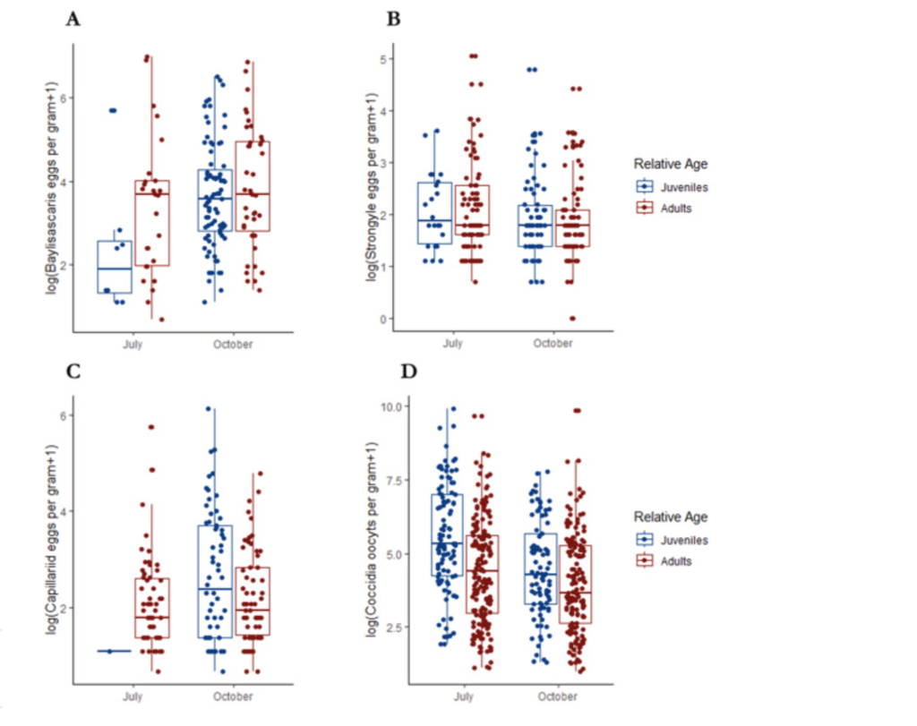

### b.

The authors very clearly represent their statistics in Figure 2. The x- and y-axes are logically labeled, and each boxplot includes both the summary statistics and the raw data points, which enhances transparency and interpretability. By showing individual data points alongside medians and spread, the figure makes patterns and variability easy to detect across seasons and age groups.

### c.

While the figure is effective overall, the tight spacing of the four boxplots makes the layout feel visually clustered. The use of many data points, combined with dense boxplot lines and colors, creates a low data:ink ratio, there’s a lot of visual “ink” relative to the amount of information being conveyed. This can make the figure feel clumpy and slightly overwhelming, especially on a first look.

### d.

To improve the clarity and overall impact of Figure 2, I would recommend increasing the spacing between the four panels to reduce visual clutter and give each subplot more breathing room. This would help the viewer focus on one comparison at a time without feeling overwhelmed. I would also consider using lighter or semi-transparent dots for the raw data points to prevent them from visually clumping and obscuring the boxplot structure. Additionally, it might be helpful to add labels directly to the panels indicating age class, rather than relying solely on axis labels, which can be easy to miss. Finally, simplifying the color scheme or using slightly more muted tones could reduce the figure’s overall intensity and improve readability without sacrificing information. These changes would enhance the figure’s effectiveness while maintaining the integrity of the data.